# Introduction to Databases and Data Modelling

Author

Oliver Gregory

Published

October 1, 2024

# Basic Concepts

## File based approach

A file based approach does not require database software. Instead, each user defines and implements the files needed for a specific application. This approach has several disadvantages:

- Duplicated data.
- Separation and isolation.
- Data is physically dependent on the application.

## Databases

### What is a database?

Data is a collection of known **facts** that can be recorded and that have implicit meaning.

A database is a collection of **related** and **logically coherent** data, built for a specific purpose.

### How do we design a database?

#### Simplify and identify

- Subjects and nouns → relations.
- Objects → attributes/keys.
- Predicates → relationships.
- Numerals → cardinalities.

#### Example

A university database for maintaining information about students, courses, and grades. Each student is referred by their name, unique number, class and major. Each course has a name, a unique code, the number of credits or hours, and the department to which it belongs. Some courses can have another course as a prerequisite. Courses are offered within sections, and each section contains a number, the course number, the semester, the year and the instructor’s name. The students receive a grade report containing all the grades they completed across sections.

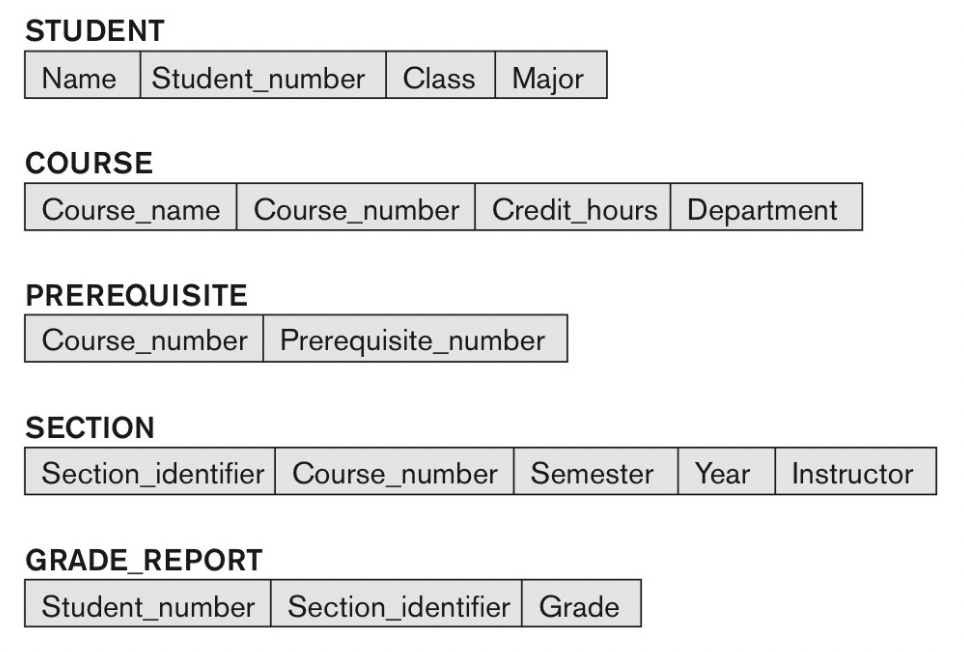

## Database management systems

### What is a DBMS?

### Characteristics of a DBMS

### Database Actors

### Three-Schema Architecture

### Modules and interactions

### Architecture of a DBMS